# DeepLearning_Final

## Yelp Sentiment Analysis - Report 3

### Submitted By-

Nibhrat Lohia, Peter Wendel, Raunak Mundada

### Abstract

Yelp reviews shared by service users for businesses are valuable for both business owners and prospective customers. The reviews consists of text description, star ratings, reviewer’s information etc. People can also vote on user reviews if they find it useful, funny or cool. The aim of our project is to predict sentiments and the status of the restaurant in a 3 month window, using the enormous review data released by Yelp. Here, we plan to conduct a sentiment and reviews analysis of the text description of reviews received for businesses in Charlotte. The idea is to find attributes that result in high ratings and thus suggest improvements in certain services in order to attract more customers meanwhile keeping check on the failure of businesses. Some of the questions we will be interested in includes; how well we can guess a review's rating from its text alone? How accurately we can predict the failure of a business using the reviews business has recieved? Can we extract tips from reviews?

### Preparation

As discussed in the previous projects, the user review data has been publicly released by Yelp for dataset challenge (https://www.yelp.com/dataset_challenge). The released data consists of 2.7M reviews and 649K tips by 687K users for 86K businesses. However, to simplify our approach, we have only considered review data of Charlotte City. We used 3 major categories of data namely; Business, Review and User. These broad categories consists of attributes of similar class, the details of which were listed in the previous report. The final variables used for the analysis are discussed in detail whenever they appear or are added.

The review data is a complex dataset across multiple dimensions. The attributes we have used are mostly those which have at least 70% data present and thus are statistically significant. The only feature that is not allowed for missing values is the business ID. The decision to remove such rows were taken for the following reasons:

1. They constitute of less than 1% of total restaurants and are statistically insignificant.
2. There is no other way that these business ID’s can be recovered thus making the merging process practically impossible.

For the User's dataset, we have classified users based on clustering algorithms and thus have reduced the features of that dataset to 1. We have also used PCA on the clusters to have a better distinction among them. Thus in this dataset, we finally have 10 clusters to classify the type of users and represent their attributes. The clustering procedure used is K-Means.

For the Reviews Dataset, we have used sentiment analysis and Natural Language Processing methods to quantify the sentiments in the text reviews. Each review is processed in an Analyzer which compares words from existing dictionaries of sentiments and is assigned probabilities in 3 categories, namely: Negative, Neutral and Positive. These three probabilities are further used as features averaged for each business and used as features. The Final dataset is merged on Business ID for Business, Sentiment and Users Cluster Data.

#### Task To Solve:

In this third part of the project, we continue our search for better techniques and models to predict the future of the business and classify if they are likely to go out of business in the coming quarter. These results can further be used in discovering factors that lead to failures and thus help businesses to improve upon their existing revenues. Also, if required, a cost analysis can be performed to test the implication, for example; the cost associated with misclassifying a potential shutdown of the business or misclassifying a popular & growing restaurant can be compared. In this part of the project, we will evaluate the performance of various deep learning techniques for our data set. These techniques will be discussed subsequently.

#### Metrics used for general evaluation:

To evaluate the algorithm’s final performance, log-loss is used to minimize the number of false classifications. Log loss is defined as the natural logarithm of the likelihood function for a Bernouli random distribution. For cases in which there are only two possible outcomes, the formula for the metric is defined as follows:

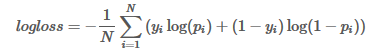

```python
from IPython.display import Image
Image(filename='C:/Users/Nibhrat/Desktop/equation.png')
```

This metric uses the predicted probability of an outcome to penalize outputs that are both extremely confident and misclassified. As shown in the formula, any value with a high accuracy score that is misclassified will have a very high weight. By attempting to minimize this metric, the final model will select a model that is strong at correctly identifying the correct class for each data point. This should prevent false positives, in which the model predicts that the restaurant is performing well when in actuality it could be on the brink of closing. Also, the accuracy measure can be a reflectective of the F1 and Recall scores used in the last report if the measure is relatively high and thus demonstrates high F1 scores. Thus both the Log Loss and Accuracy are used as a measure of evaluation (Preferance is given to Log Loss measure).

### Modeling:

Continuing our search for algorithms that can predict the future status of busniesses based on the reviews they recieve, we aim to use the modern deep learning architectures for this project. In particular, we have used LSTM (Long Short Term Memory) and the more advanced GRU (Gated Recurrent Unit) architectures for our problem set. Both of these architectures are proven to be highly successful/accurate in Time Series problems (similar to the one we have) through different independent researchs (1). The Long Short-Term Memory (LSTM) proposed by Hochreiter and Schmidhuber [1997] and modified by Graves [2013], and the recurrent unit (GRU) proposed by Cho et al. [2014] work on the same principle of gating units that modulate the flow of information inside the unit. The difference lies in having a separate memory cell which the LSTM have and the GRU lacks. The GRU, unlike LSTM exposes the whole state each time. A flow diagram of the architecture we used is given below:

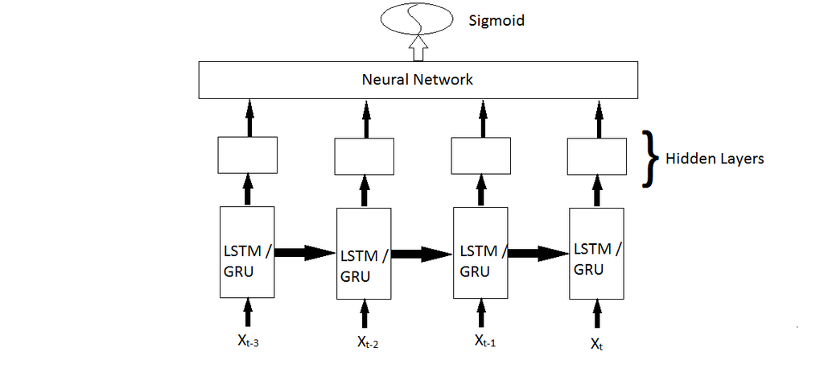

```python
Image(filename='C:/Users/Nibhrat/Desktop/LSTM GRU Layers.png')
```

Both of these nodes are represented below:

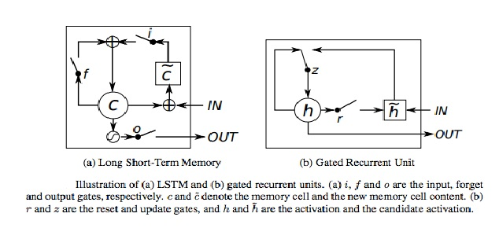

```python
Image(filename='C:/Users/Nibhrat/Desktop/LSTM Node.jpg')
```

Both of these architectures or RNN's in general are well suited for certain time series analysis as shown by F. Gers [2000]. Others have demonstrated similar results. Our architecture consists of LSTM layer → Dropout → LSTM → Neural Network layer → Sigmoid Activation. For a GRU processor, the LSTM unit is replaced by the GRU Unit. Considering we have a similar time series problem as discussed in these papers and in class with Dr. Larson, LSTM and GRU are expected to give better results than traditional RNN's.

```python
import sys
import pandas as pd
import numpy as np
# Time Series Testing
import keras.callbacks
from keras.models import Sequential
from keras.layers.core import Dense, Activation, Dropout
from keras.layers.recurrent import LSTM,GRU
from keras.wrappers.scikit_learn import KerasClassifier
from sklearn.model_selection import GridSearchCV

import plotly
from plotly.offline import download_plotlyjs, init_notebook_mode, plot, iplot
from plotly.graph_objs import *
plotly.offline.init_notebook_mode()
```

# Data Preparation

Most of the preprocessing have already been discussed in previous reports. Minimal changes are made and the dataset is shaped for our requirements.

```python
# Function to create business-wise matrices for the given time step

def reshape_arr(X_data, Y_data):
    x_arr = np.array(X_data[0])
    y_arr = np.array(Y_data[0])
    for x_item,y_item in zip(X_data[1:],Y_data[1:]):
        try:
            x_arr = np.concatenate((x_arr,np.array(x_item)),axis=0)
            y_arr = np.concatenate((y_arr,np.array(y_item)),axis=0)
        except ValueError:
            print("No data present. Check data preparation.")
    return(x_arr, y_arr)

def train_test_split(X_data, Y_data,prop=0.2):
    np.random.seed(1)
    test_sam = int(len(X_data)*prop)
    print ("Test data proportion:", test_sam)
    test_id = set(list(np.random.choice(range(len(X_data)), test_sam)))

    X_test = [X_data[ix] for ix in test_id]
    Y_test = [Y_data[ix] for ix in test_id]

    X_train = [i for j, i in enumerate(X_data) if j not in test_id]
    Y_train = [i for j, i in enumerate(Y_data) if j not in test_id]

    X_train, Y_train = reshape_arr(X_train, Y_train)
    X_test, Y_test = reshape_arr(X_test, Y_test)
    return(X_train, Y_train, X_test, Y_test)

def data_prep(df,time_step=4):
    X_data = []
    Y_data = []
    for business_id in df.business_id.unique():
        sub = df[df.business_id == business_id]
        sub = sub.sort_values(by='Period_StartDate', inplace=False)
        y = pd.Series(sub.Open_Flag)
        sub.drop(['business_id','Period_StartDate',
                  'Open_Flag'],axis=1,inplace=True)
        # One-hot encode categorical variables
        sub = pd.get_dummies(sub)
        N,n_features = sub.shape
        inp_data = []
        op_data = []
        for ix in range(N-time_step+1):
            temp_x = np.array(sub.iloc[ix:ix+time_step,:])
            temp_y = np.array(y.iloc[ix:ix+time_step])
            if temp_x.shape[0] < time_step:
                # Pad X's with zeros
                padzeros = np.zeros((time_step,temp_x.shape[1]))
                padzeros[:temp_x.shape[0],:temp_x.shape[1]] = temp_x
                temp_x = padzeros
                # Pad the y's with zeros
                a = np.zeros(time_step)
                a[:temp_y.shape[0]] = y
                temp_y = a

            inp_data.append(temp_x)
            op_data.append(temp_y)
        X_data.append(inp_data)
        Y_data.append(op_data)

    # Split into train and test
    x_train, y_train, x_test, y_test = train_test_split(X_data, Y_data)
    return(x_train, y_train, x_test, y_test)
#     x_arr, y_arr = reshape_arr(X_data, Y_data)
#     return(X_data,Y_data)

def read_data():
    print("Loading Data after preprocessing")
    yelp_df = pd.read_csv("./Data/Feature_Engineering.csv",parse_dates=[2],
                         index_col=0)
    yelp_df.drop(['Start_Review_Date','Last_Review_Date','Cluster_count'],
                axis=1, inplace=True)
    #Drop businesses that have less than 12 months of data (ad-hoc analysis)
    business_id_drop = ['WC-pp8AA3vCtcXfcKO8dUQ','1hqvPXcoXiewmALiVtzmnw',
                       '2phadFQpAga7PLooU-IaDQ','4533HHCXeTlU_cCjPnq0Fg',
                       'vZu6Sfz0-2Zvw0PRXaQ6RQ','tR-9tTMPmK8MQkuoC8Xd8g',
                       '5pmY6tckFPlFy1BW2zAU9A','j75L7p-N-AnaT1g8zFcatg',
                       'KOtz_vAJ5mjnIBAuDGE9gg','S5BAzIpkheyP3c_7uybWNA',
                       'p9QgUYZVm-ze5hpaUyo7Xg','NTHQGBG-ZIdJW_AbBXoJBw',
                       'evzxYJV8nvDn2uUT8aZ6iQ']
    yelp_df = yelp_df.drop(yelp_df[yelp_df.business_id.isin(business_id_drop)].index,
                          axis=0, inplace=False)
#     x_arr, y_arr = data_prep(yelp_df,time_step=4)
    x_train, y_train, x_test, y_test = data_prep(yelp_df,time_step=4)
    return (x_train, y_train, x_test, y_test)
#     return(x_arr, y_arr)
```

```python
# x_arr, y_arr = read_data()
x_train, y_train, x_test, y_test = read_data()
```

```
Loading Data after preprocessing
Test data proportion: 540
```

```python
print("X training shape:",x_train.shape)
print("Y training shape:",y_train.shape)
```

```
X training shape: (39449, 4, 69)
Y training shape: (39449, 4)
```

```python
print("X test shape:",x_test.shape)
print("Y test shape:",y_test.shape)
```

```
X test shape: (8480, 4, 69)
Y test shape: (8480, 4)
```

# LSTM

As discussed before, we deployed LSTM architecture. The processing is shown below:

```python
# https://gist.github.com/lukovkin/1aefa4509e066690b892
def build_model(layers = [69,4,100,4]):
    model = Sequential()
    model.add(LSTM(
        input_dim=layers[0],
        output_dim=layers[1],
        return_sequences=True))
    model.add(Dropout(0.2))
    model.add(LSTM(layers[2],
                  return_sequences=False))
    model.add(Dense(output_dim=layers[3]))
    model.add(Activation('sigmoid'))
    model.compile(loss='binary_crossentropy',optimizer='adam',metrics = ['accuracy'])

    return (model)
```

## Grid Search for LSTM

#### Scikit learn wrapper for keras

###### http://machinelearningmastery.com/grid-search-hyperparameters-deep-learning-models-python-keras/

```python
%%time
model = KerasClassifier(build_fn = build_model,nb_epoch=50,verbose=0)
batch_size = np.array([100, 300])
layer_size = [[69,4,20,4],[69,4,50,4],[69,4,100,4]]
param_grid = dict(batch_size=batch_size,layers=layer_size)
grid = GridSearchCV(estimator=model, param_grid=param_grid)
grid_result = grid.fit(x_train, y_train)
```

```
Wall time: 1h 48min 57s
```

```python
# summarize results
print("Best: %f using %s" % (grid_result.best_score_, grid_result.best_params_))
means = grid_result.cv_results_['mean_test_score']
stds = grid_result.cv_results_['std_test_score']
params = grid_result.cv_results_['params']
for mean, stdev, param in zip(means, stds, params):
    print("%f (%f) with: %r" % (mean, stdev, param))
tempmean = mean
tempstdev = stdev
tempparam = param
```

```
Best: 0.990963 using {'batch_size': 300, 'layers': [69, 4, 100, 4]}
0.990773 (0.002723) with: {'batch_size': 100, 'layers': [69, 4, 20, 4]}
0.990817 (0.003570) with: {'batch_size': 100, 'layers': [69, 4, 50, 4]}
0.990710 (0.003259) with: {'batch_size': 100, 'layers': [69, 4, 100, 4]}
0.990538 (0.003625) with: {'batch_size': 300, 'layers': [69, 4, 20, 4]}
0.990684 (0.003441) with: {'batch_size': 300, 'layers': [69, 4, 50, 4]}
0.990963 (0.003426) with: {'batch_size': 300, 'layers': [69, 4, 100, 4]}
```

The best comibination of batch size = 300 and layers [69, 4, 100, 4] is selected.

### Statistical Significance of the Metric found:

We have used 95% confidence interval for the accuracy measure, which was discussed before as one the measures that is appropriate. The results are discussed below:

```python
trace0 = Scatter(
    x = list(range(0,6,1)),
    y = means + 1.96*stds,
    mode='lines',
    name='95% Uncertainty top',
    line=dict(
        color='rgb(0, 255, 255)',
    )
)
trace1 = Scatter(
    x = list(range(0,6,1)),
    y = means - 1.96*stds,
    fill='tonexty',
    mode='lines',
    name='95% uncertainty bottom',
    line=dict(
        color='rgb(0, 255, 255)',
    )
)

trace2 = Scatter(
    x = list(range(0,6,1)),
    y = means,
    name='Average Accuracy',
    line=dict(
        color='rgb(199, 121, 093)',
    )
)
data = [trace0, trace1, trace2]

layout = Layout(
    xaxis=dict(title='Parmeters combination'),
    yaxis=dict(title='Mean Accuracy'),
    title='Test scores for different parameters (LSTM)',
    showlegend = False)

fig = Figure(data=data, layout=layout)
iplot(fig)
```

[interactive chart not shown]

As seen from the 95% confidence band, the accuracy is statistically significant and doesn't contain zero. The best model so picked using the gridsearch is now tested on the Test Dataset. The results are discussed as:

```python
# Evaluate model on test dataset
model = build_model(layers = [69, 4, 100, 4])
model.fit(x_train, y_train, nb_epoch = 100, batch_size=300)
scores = model.evaluate(x_test, y_test, verbose=0)
print("%s: %0.2f%%" % (model.metrics_names[0], scores[0]*100))
```

```
loss: 3.33%
```

As can be seen from the results, the log-loss is reduced upto 0.0330 with the accuracy around 99%. The results will be critically discussed in the deployment section. Another architecture we were interested in is GRU. The processing is shown below:

# GRU

```python
def build_model(layers = [69,4,100,4]):
    model = Sequential()
    model.add(GRU(
        input_dim=layers[0],
        output_dim=layers[1],
        return_sequences=True))
    model.add(Dropout(0.2))
    model.add(GRU(layers[2],
                  return_sequences=False))
    model.add(Dense(output_dim=layers[3]))
    model.add(Activation('sigmoid'))
    model.compile(loss='binary_crossentropy',optimizer='adam',metrics = ['accuracy'])
    return (model)
```

```python
print("%s: %.2f%%" % (model.metrics_names[0], scores[0]*100))
```

```
loss: 3.33%
```

## Grid search for GRU

```python
%%time
model = KerasClassifier(build_fn = build_model,nb_epoch=100,verbose=0)
batch_size = np.array([100, 300])
layer_size = [[69,4,20,4],[69,4,50,4],[69,4,100,4]]
param_grid = dict(batch_size=batch_size, layers=layer_size)
grid = GridSearchCV(estimator=model, param_grid=param_grid)

grid_result = grid.fit(x_train, y_train)

# summarize results
print("Best: %f using %s" % (grid_result.best_score_, grid_result.best_params_))
means = grid_result.cv_results_['mean_test_score']
stds = grid_result.cv_results_['std_test_score']
params = grid_result.cv_results_['params']
for mean, stdev, param in zip(means, stds, params):
    print("%f (%f) with: %r" % (mean, stdev, param))
tempmeans = mean
tempstdev = stdev
tempparam = param
```

```
Best: 0.991172 using {'batch_size': 300, 'layers': [69, 4, 20, 4]}
0.991166 (0.003345) with: {'batch_size': 100, 'layers': [69, 4, 20, 4]}
0.991058 (0.003362) with: {'batch_size': 100, 'layers': [69, 4, 50, 4]}
0.990760 (0.003686) with: {'batch_size': 100, 'layers': [69, 4, 100, 4]}
0.991172 (0.003266) with: {'batch_size': 300, 'layers': [69, 4, 20, 4]}
0.990881 (0.003513) with: {'batch_size': 300, 'layers': [69, 4, 50, 4]}
0.990304 (0.003690) with: {'batch_size': 300, 'layers': [69, 4, 100, 4]}
Wall time: 4h 53min 53s
```

The best combination of batch size = 300 and layers [69, 4, 20, 4] is selected for testing.

### Statistical significance of the metric found

We have used 95% confidence interval for the accuracy measure, which was discussed before as one the measures that is appropriate. The results are discussed below:

```python
trace0 = Scatter(
    x = list(range(0,6,1)),
    y = means + 1.96*stds,
    mode='lines',
    name='95% Uncertainty top',
    line=dict(
        color='rgb(0, 255, 255)',
    )
)
trace1 = Scatter(
    x = list(range(0,6,1)),
    y = means - 1.96*stds,
    fill='tonexty',
    mode='lines',
    name='95% uncertainty bottom',
    line=dict(
        color='rgb(0, 255, 255)',
    )
)

trace2 = Scatter(
    x = list(range(0,6,1)),
    y = means,
    name='Average F-score',
    line=dict(
        color='rgb(199, 121, 093)',
    )
)
data = [trace0, trace1, trace2]

layout = Layout(
    xaxis=dict(title='Parmeters combination'),
    yaxis=dict(title='Mean F-measure'),
    title='Test scores for different parameters (GRU Cell unit)',
    showlegend = False)

fig = Figure(data=data, layout=layout)
iplot(fig)
```

[interactive chart not shown]

As seen from the 95% confidence band, the accuracy is statistically significant and doesn't contain zero. The best model so picked using the gridsearch is now tested on the Test Dataset. The results are discussed as:

```python
# Evaluate model on test dataset
model = build_model(layers = [69, 4, 20, 4])
model.fit(x_train, y_train, nb_epoch = 100, batch_size=300)
scores = model.evaluate(x_test, y_test, verbose=0)
print("%s: %0.2f%%" % (model.metrics_names[0], scores[0]*100))
```

[output not shown]

### Deployment:

The results from this model looks promising and can be useful for any qualifying restaurant in the Yelp database. It could be used as a statistically backed method to help identify struggling restaurants and show how other similar restaurants are capable of succeeding. By identifying the traits of a successful restaurant, the model could be used to help these struggling restaurants by identifying potential areas of growth. This could help reduce the restaurant turnover rates and allow restaurants to improve their longevity. The model is currently only tuned to represent one city’s restaurant data, but could be scaled to intake data from all reviews present within the Yelp databases. The insights gained from such an implementation could be invaluable for restaurants of all types and sizes. However, one may argue about the genneralization capability of this model for now. Since we used only a subset (Charlotte City) of the data and the accuracy is too overwhelming(99.1%), we have reasons to further investigate and elimminate any possible overtraining that might have occurred. If the training sets include the data from more generic locations, the model can increase it's generalization capabilty. In the present state, the model is highly useful for businesses in Charlotte.

### References

1. Chung, Junyoung; Gulcehre, Caglar; Cho, KyungHyun; Bengio, Yoshua (2014). "Empirical Evaluation of Gated Recurrent Neural Networks on Sequence Modeling". arXiv:1412.3555
2. F. Gers, D. Eck, J. F. Schmidhuber, “Applying LSTM to time series predictable through time-window approaches” (IDSIA-IDSIA-22-00, 2000); www.idsia.ch/felix/Publications.html.
3. S. Hochreiter and J. Schmidhuber. Long short-term memory. Neural Computation, 9(8):1735–1780, 1997.
4. K. Cho, B. van Merrienboer, D. Bahdanau, and Y. Bengio. On the properties of neural machine translation: Encoder-decoder approaches. arXiv preprint arXiv:1409.1259, 2014.
5. A. Graves. Practical variational inference for neural networks. In Advances in Neural Information Processing Systems, pages 2348–2356, 2011.

#### THANK YOU FOR A GREAT SEMESTER